# Descriptive Exploration

This document is intended to explore the descriptive distributions and relationships between the variables in the Experiment 1 data. Previous RMarkdown notebooks included preprocessing and matching previously reported statistics and means.

## Document Outline

Because we’re dealing with discrete, experimentally-manipulated factors, it limits the scope of what we can investigate descriptively. So the approach will be as follows:

- Assess the distribution of the outcome.
- Analyze bivariate relationships between all factors and outcome.
- Plot theoretically interesting parts of the design.

Load libraries and data:

```r
library(tidyverse)
library(data.table)
```

```r
current_data <- fread('../data/exp1_clean.csv', stringsAsFactors = TRUE)
current_data <- current_data %>%
  mutate(cycle = as.factor(cycle))
head(current_data)
```

|  | subject | context | item | block | item_type | cycle | rt |
| --- | --- | --- | --- | --- | --- | --- | --- |
| 1 | 200 | homo | parsnip | 1 | category | 1 | 657 |
| 2 | 200 | homo | lettuce | 1 | category | 1 | 494 |
| 3 | 200 | homo | parsnip | 1 | category | 2 | 501 |
| 4 | 200 | homo | carrot | 1 | category | 2 | 551 |
| 5 | 200 | homo | parsnip | 1 | category | 3 | 524 |
| 6 | 200 | homo | carrot | 1 | category | 3 | 555 |

```r
str(current_data)
```

```
'data.frame':   6271 obs. of  7 variables:
 $ subject  : int  200 200 200 200 200 200 200 200 200 200 ...
 $ context  : Factor w/ 2 levels "het","homo": 2 2 2 2 2 2 2 2 2 2 ...
 $ item     : Factor w/ 24 levels "axe","ball","bird",..: 16 15 16 6 16 6 16 16 6 13 ...
 $ block    : int  1 1 1 1 1 1 1 1 1 1 ...
 $ item_type: Factor w/ 2 levels "RAT","category": 2 2 2 2 2 2 2 2 2 1 ...
 $ cycle    : Factor w/ 5 levels "1","2","3","4",..: 1 1 2 2 3 3 4 5 5 1 ...
 $ rt       : int  657 494 501 551 524 555 507 690 510 514 ...
```

### Assess Outcome Variable

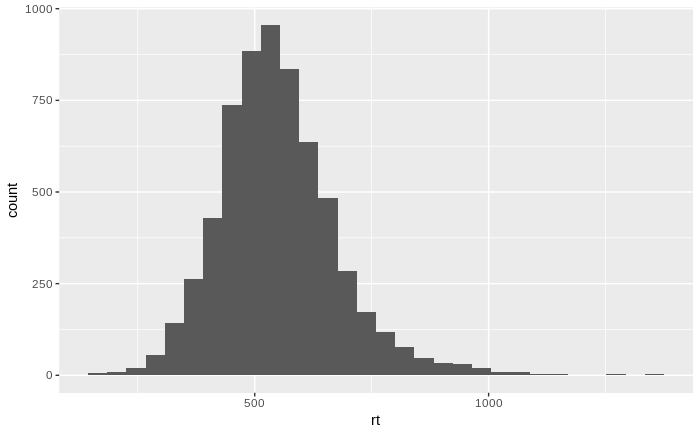

```r
current_data %>%
  ggplot(aes(x = rt)) + geom_histogram()
```

```r
current_data %>%
  summarize('Overall RT Mean' = mean(rt), 'Overall RT SD' = sd(rt))
```

| Overall RT Mean | Overall RT SD |
| --- | --- |
| 549.4986 | 128.0457 |

### Assess Bivariate Relationships

I’ll cheat and start by focusing on a variable that I know (from the ANOVA) significantly impacted RTs——context.

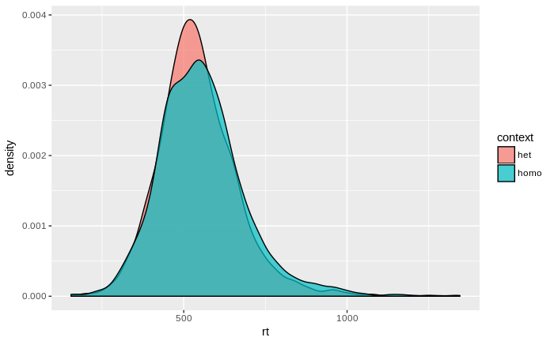

```r
current_data %>%
  ggplot(aes(x = rt)) + geom_density(aes(fill = context), alpha = .7)
```

One thing I’m noticing here is that there might just be fewer observations for the homogeneous context vs heterogeneous context condition. It could also be that the homogeneous distribution is skewed slightly more to the right, giving the impression that there’s less data. It’s worth looking at cell counts in the design (disregarding subject for the time being):

```r
current_data %>%
  group_by(context, block, item_type, cycle) %>%
  summarize(count = n()) %>%
  arrange(item_type, context, block) %>%
  unite(variable, item_type, context, block) %>%
  spread(variable, count)
```

| cycle | category_het_1 | category_het_2 | category_homo_1 | category_homo_2 | RAT_het_1 | RAT_het_2 | RAT_homo_1 | RAT_homo_2 |
| --- | --- | --- | --- | --- | --- | --- | --- | --- |
| 1 | 162 | 161 | 158 | 159 | 161 | 160 | 136 | 153 |
| 2 | 160 | 160 | 159 | 158 | 161 | 162 | 138 | 162 |
| 3 | 162 | 155 | 159 | 157 | 164 | 162 | 137 | 159 |
| 4 | 157 | 164 | 149 | 159 | 164 | 157 | 137 | 157 |
| 5 | 163 | 163 | 156 | 157 | 162 | 165 | 136 | 160 |

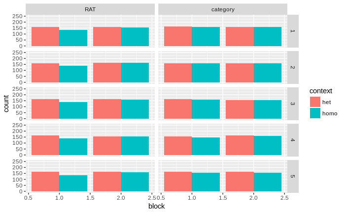

```r
current_data %>%
  group_by(context, block, item_type, cycle) %>%
  summarize(count = n()) %>%
  arrange(item_type, context, block) %>%
  ggplot(aes(x = block, y = count)) + geom_bar(stat= 'identity', aes(fill = context), position = 'dodge') + facet_grid(cycle ~ item_type) + ylim(0,250)
```

Let’s look at the distribution of RTs across each of the predictors.

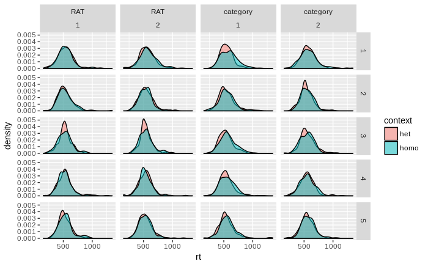

```r
current_data %>%
  ggplot(aes(x = rt)) + geom_density(aes(fill = context), alpha = .5) + facet_grid(cycle ~ item_type + block)
```

It looks like, on the whole, RTs tend to be slower for homogeneous relative to heterogeneous contexts. It also looks like there’s just more variability in RTs for homogeneous contexts.

### Plotting interesting parts of the design

The core interaction for the semantic interference theory is that participants will be slower to name items when presented in a homogeneous category, and that this cost will inflate over time.  
The present study additionally posits that RAT items will be treated similarly to related-category items, but *only* if the solution to the RAT is known (i.e., if participants are aware of the connection between the items). So here’s an order in which we’ll look at the trends in the data:

- context X cycle (common category only)
- Should see RTs slower for homogeneous context, and the difference should increase over cycles
- context X cycle X item type (for block 1 only)
- If participants aren’t treating RATs like common category items when they *don’t* know the solution, we should only see the 2-way interaction between context and cycle for common-category item types (not RATs) in block 1
- context X cycle X item type (for block 2 only)
- In block 2 (when participants are given the RAT solution), responses should look similar across item types

**Context by cycle interaction (for common category only)

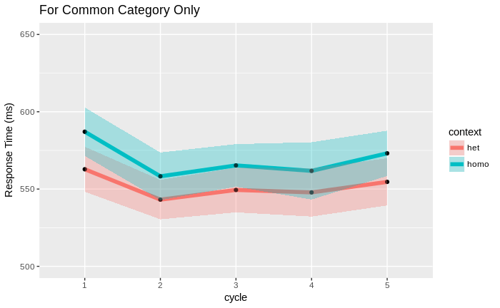

```r
N <- current_data %>%
  group_by(subject) %>%
  summarize(n()) %>%
  nrow(.)
current_data %>%
  filter(item_type == 'category') %>%
  group_by(subject, context, cycle, block) %>%
  summarize(r_time = mean(rt)) %>%
  group_by(context, cycle) %>%
  summarize(rt = mean(r_time), se = sd(r_time) / sqrt(N)) %>%
  ggplot(aes(x = cycle, y = rt, group = context)) + geom_line(aes(color = context), size = 2) +
  geom_point() +
  geom_ribbon(aes(ymin = rt - se, ymax = rt + se, fill = context), alpha = .3) + ylab('Response Time (ms)') + ggtitle('For Common Category Only') + ylim(500,650)
```

RTs for homogeneous items is certainly slower than for heterogeneous, but that difference doesn’t appear to increase over cycles. Now let’s break this down by item type for block 1 only.

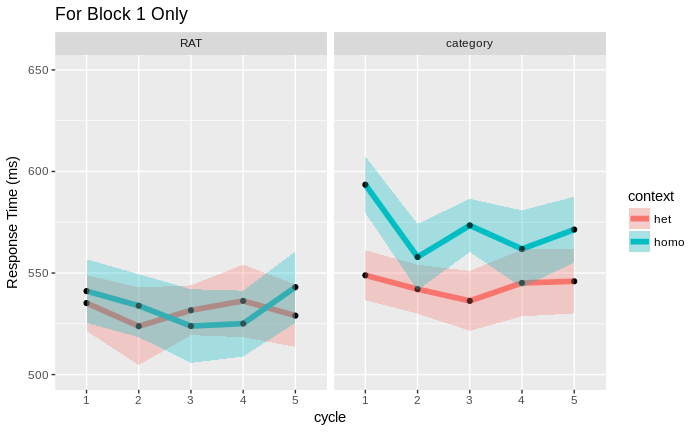

```r
current_data %>%
  filter(block == '1') %>%
  group_by(subject, context, cycle, block, item_type) %>%
  summarize(r_time = mean(rt)) %>%
  group_by(context, cycle, item_type) %>%
  summarize(rt = mean(r_time), se = sd(r_time) / sqrt(N)) %>%
  ggplot(aes(x = cycle, y = rt, group = context)) + geom_line(aes(color = context), size = 2) +
  geom_point() +
  geom_ribbon(aes(ymin = rt - se, ymax = rt + se, fill = context), alpha = .3) + ylab('Response Time (ms)') + ggtitle('For Block 1 Only') + facet_wrap(~item_type) + ylim(500,650)
```

It’s not clear that the two-way interaction between cycle and context is coming through for category item types during block 1, but it *is* clear that there doesn’t appear to be such a two-way interaction for RATs.  
Now we’ll compare this to data from block 2, where participants are aware of the solution to RATs and we’d expect RAT data to more closely approximate the category data.

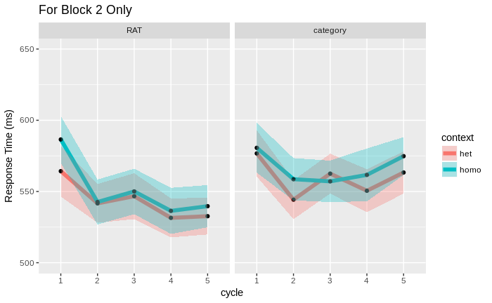

```r
current_data %>%
  filter(block == '2') %>%
  group_by(subject, context, cycle, block, item_type) %>%
  summarize(r_time = mean(rt)) %>%
  group_by(context, cycle, item_type) %>%
  summarize(rt = mean(r_time), se = sd(r_time) / sqrt(N)) %>%
  ggplot(aes(x = cycle, y = rt, group = context)) + geom_line(aes(color = context), size = 2) +
  geom_point() +
  geom_ribbon(aes(ymin = rt - se, ymax = rt + se, fill = context), alpha = .3) + ylab('Response Time (ms)') + ggtitle('For Block 2 Only') + facet_wrap(~item_type) + ylim(500,650)
```

```r
head(current_data)
```

|  | subject | context | item | block | item_type | cycle | rt |
| --- | --- | --- | --- | --- | --- | --- | --- |
| 1 | 200 | homo | parsnip | 1 | category | 1 | 657 |
| 2 | 200 | homo | lettuce | 1 | category | 1 | 494 |
| 3 | 200 | homo | parsnip | 1 | category | 2 | 501 |
| 4 | 200 | homo | carrot | 1 | category | 2 | 551 |
| 5 | 200 | homo | parsnip | 1 | category | 3 | 524 |
| 6 | 200 | homo | carrot | 1 | category | 3 | 555 |

```r
subject_means <- current_data %>%
  group_by(subject, context, cycle, block, item_type) %>%
  summarize(rt = mean(rt)) %>%
  mutate(code = 'subject') %>%
  rename(id = subject)


random_means <- current_data %>%
  group_by(item, context, cycle, block, item_type) %>%
  summarize(rt = mean(rt)) %>%
  mutate(code = 'item') %>%
  rename(id = item) %>%
  rbind(subject_means) %>%
  ungroup() %>%
  mutate(id = as.factor(id),
         code = as.factor(code))
```

[output not shown]

## 6-11 Plot the marginal three-way interaction

block X context X item type

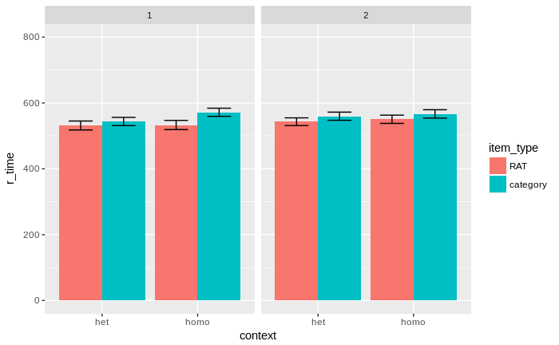

```r
current_data %>%
  mutate(block = as.factor(block)) %>%
  group_by(subject, block, context, item_type) %>%
  summarize(rt = mean(rt)) %>%
  group_by(block, context, item_type) %>%
  summarize(r_time = mean(rt), se = sd(rt) / sqrt(n())) %>%
  ggplot(aes(x = context, y = r_time, group = item_type)) + geom_bar(position = 'dodge', aes(fill = item_type), stat = 'identity') +
  geom_errorbar(aes(ymin = r_time - se, ymax = r_time + se), position = position_dodge(width = .9), width = .5) + facet_wrap(~block) + ylim(0, 800)
```